# Prak 3 MPDW

Kezia Imanuella Victoria

2026-09-03

```r
#PACKAGES
#install.packages("dLagM") #install jika belum ada
#install.packages("dynlm") #install jika belum ada
#install.packages("MLmetrics") #install jika belum ada
library(dLagM)
library(dynlm)
library(MLmetrics)
library(lmtest)
library(car)
```

# Data 1

```r
periode <- 1:20
market <- c(3.63,4.20,3.33,4.54,2.89,4.87,4.90,5.29,6.18,7.20,7.25,6.09,6.80,8.65,8.43,8.29,7.18,7.90,8.45,8.23)
price <- c(0.97,0.95,0.99,0.91,0.98,0.90,0.89,0.86,0.85,0.82,0.79,0.83,0.81,0.77,0.76,0.80,0.83,0.79,0.76,0.78)
dtmarket <- data.frame(periode, market, price)
dtmarket <- cbind(market,price)
dtmarket <- as.data.frame(dtmarket)
dtmarket
```

```
##    market price
## 1    3.63  0.97
## 2    4.20  0.95
## 3    3.33  0.99
## 4    4.54  0.91
## 5    2.89  0.98
## 6    4.87  0.90
## 7    4.90  0.89
## 8    5.29  0.86
## 9    6.18  0.85
## 10   7.20  0.82
## 11   7.25  0.79
## 12   6.09  0.83
## 13   6.80  0.81
## 14   8.65  0.77
## 15   8.43  0.76
## 16   8.29  0.80
## 17   7.18  0.83
## 18   7.90  0.79
## 19   8.45  0.76
## 20   8.23  0.78
```

## Pembagian Data

```r
#SPLIT DATA
train<-dtmarket[1:15,]
test<-dtmarket[16:20,]
```

```r
#data time series
train.ts<-ts(train)
test.ts<-ts(test)
data.ts<-ts(dtmarket)
```

```r
#MODEL KOYCK
model.koyck <- koyckDlm(x = train$price, y = train$market, intercept = TRUE)
summary(model.koyck)
```

```
##
## Call:
## "Y ~ (Intercept) + Y.1 + X.t"
##
## Residuals:
##     Min      1Q  Median      3Q     Max
## -0.9997 -0.3171  0.0652  0.2586  1.1063
##
## Coefficients:
##             Estimate Std. Error t value Pr(>|t|)
## (Intercept)  15.4328    14.7611   1.046    0.318
## Y.1           0.3651     0.5152   0.709    0.493
## X.t         -13.4703    13.8869  -0.970    0.353
##
## Residual standard error: 0.599 on 11 degrees of freedom
## Multiple R-Squared: 0.9037,  Adjusted R-squared: 0.8861
## Wald test: 37.92 on 2 and 11 DF,  p-value: 1.16e-05
##
## Diagnostic tests:
## NULL
##
##                             alpha      beta       phi
## Geometric coefficients:  24.30938 -13.47028 0.3651498
```

```r
AIC(model.koyck)
```

```
## [1] 30.00231
```

```r
BIC(model.koyck)
```

```
## [1] 32.55853
```

Didapat bahwa peubah $X_t$ dan $Y_{t-1}$ memiliki nilai $P\text{-Value} > 0.05$. Hal ini menunjukkan bahwa peubah $X_t$ dan $Y_{t-1}$ tidak berpengaruh signifikan terhadap $Y_t$.

```r
fore.koyck <- forecast(model = model.koyck, x = test$price, h = 5)
fore.koyck
```

```
## $forecasts
## [1] 7.734805 7.076847 7.375405 7.888531 7.806494
##
## $call
## forecast.koyckDlm(model = model.koyck, x = test$price, h = 5)
##
## attr(,"class")
## [1] "forecast.koyckDlm" "dLagM"
```

```r
mape.koyck <- MAPE(fore.koyck$forecasts, test$market)
mape.koyck #data test
```

```
## [1] 0.05312954
```

```r
#akurasi data training
GoF(model.koyck)
```

```
##              n       MAE         MPE       MAPE      sMAPE      MASE       MSE
## model.koyck 14 0.4215632 -0.01898878 0.08448088 0.08112884 0.4555545 0.2818772
##                 MRAE     GMRAE
## model.koyck 1.457091 0.5463437
```

```r
# DLM dengan lag X = 1 (q = 1)
cons_dlm1 <- dynlm(market ~ price + L(price), data = train.ts)

# ARDL dengan p = 1, q = 0 (hanya lag Y)
cons_ardl1 <- dynlm(market ~ price + L(market), data = train.ts)

# ARDL dengan p = 1, q = 1 (mengandung lag X dan lag Y)
cons_ardl2 <- dynlm(market ~ price + L(price) + L(market), data = train.ts)

# DLM dengan lag X sampai order 2 (q = 2)
cons_dlm2 <- dynlm(market ~ price + L(price) + L(price, 2), data = train.ts)
```

```r
summary(cons_dlm1)
```

```
##
## Time series regression with "ts" data:
## Start = 2, End = 15
##
## Call:
## dynlm(formula = market ~ price + L(price), data = train.ts)
##
## Residuals:
##     Min      1Q  Median      3Q     Max
## -0.5929 -0.2490 -0.1363  0.3539  0.6775
##
## Coefficients:
##             Estimate Std. Error t value Pr(>|t|)
## (Intercept)   25.779      1.440  17.898 1.75e-09 ***
## price        -23.725      2.837  -8.363 4.27e-06 ***
## L(price)       0.571      2.901   0.197    0.848
## ---
## Signif. codes:  0 '***' 0.001 '**' 0.01 '*' 0.05 '.' 0.1 ' ' 1
##
## Residual standard error: 0.4179 on 11 degrees of freedom
## Multiple R-squared:  0.9531, Adjusted R-squared:  0.9446
## F-statistic: 111.8 on 2 and 11 DF,  p-value: 4.917e-08
```

```r
summary(cons_ardl1)
```

```
##
## Time series regression with "ts" data:
## Start = 2, End = 15
##
## Call:
## dynlm(formula = market ~ price + L(market), data = train.ts)
##
## Residuals:
##      Min       1Q   Median       3Q      Max
## -0.56850 -0.25482 -0.08114  0.34615  0.69197
##
## Coefficients:
##             Estimate Std. Error t value Pr(>|t|)
## (Intercept)  25.3005     2.9211   8.661 3.05e-06 ***
## price       -22.7602     2.7255  -8.351 4.33e-06 ***
## L(market)     0.0269     0.1208   0.223    0.828
## ---
## Signif. codes:  0 '***' 0.001 '**' 0.01 '*' 0.05 '.' 0.1 ' ' 1
##
## Residual standard error: 0.4177 on 11 degrees of freedom
## Multiple R-squared:  0.9531, Adjusted R-squared:  0.9446
## F-statistic: 111.9 on 2 and 11 DF,  p-value: 4.891e-08
```

```r
summary(cons_ardl2)
```

```
##
## Time series regression with "ts" data:
## Start = 2, End = 15
##
## Call:
## dynlm(formula = market ~ price + L(price) + L(market), data = train.ts)
##
## Residuals:
##      Min       1Q   Median       3Q      Max
## -0.50247 -0.30360 -0.05952  0.31335  0.74004
##
## Coefficients:
##             Estimate Std. Error t value Pr(>|t|)
## (Intercept)  18.1366     7.7391   2.344   0.0411 *
## price       -23.5593     2.8404  -8.294 8.57e-06 ***
## L(price)      7.2280     7.2307   1.000   0.3411
## L(market)     0.3028     0.3013   1.005   0.3386
## ---
## Signif. codes:  0 '***' 0.001 '**' 0.01 '*' 0.05 '.' 0.1 ' ' 1
##
## Residual standard error: 0.4177 on 10 degrees of freedom
## Multiple R-squared:  0.9574, Adjusted R-squared:  0.9446
## F-statistic: 74.91 on 3 and 10 DF,  p-value: 3.731e-07
```

```r
summary(cons_dlm2)
```

```
##
## Time series regression with "ts" data:
## Start = 3, End = 15
##
## Call:
## dynlm(formula = market ~ price + L(price) + L(price, 2), data = train.ts)
##
## Residuals:
##      Min       1Q   Median       3Q      Max
## -0.55526 -0.24858 -0.08971  0.20176  0.65633
##
## Coefficients:
##              Estimate Std. Error t value Pr(>|t|)
## (Intercept)  26.29549    1.69541  15.510 8.44e-08 ***
## price       -24.13651    4.05335  -5.955 0.000214 ***
## L(price)     -0.00163    3.20631  -0.001 0.999606
## L(price, 2)   0.34290    4.21417   0.081 0.936929
## ---
## Signif. codes:  0 '***' 0.001 '**' 0.01 '*' 0.05 '.' 0.1 ' ' 1
##
## Residual standard error: 0.4366 on 9 degrees of freedom
## Multiple R-squared:  0.9553, Adjusted R-squared:  0.9404
## F-statistic: 64.06 on 3 and 9 DF,  p-value: 2.151e-06
```

```r
deviance(cons_dlm1)
```

```
## [1] 1.921133
```

```r
deviance(cons_ardl1)
```

```
## [1] 1.919254
```

```r
deviance(cons_ardl2)
```

```
## [1] 1.744895
```

```r
deviance(cons_dlm2)
```

```
## [1] 1.715214
```

Semakin kecil nilai SSE, berarti model lebih baik dalam menyesuaikan data (karena error lebih kecil).

```r
# 1. Menggunakan predict untuk model dynlm
fore.dlm1  <- predict(cons_dlm1, newdata = test)
fore.dlm2  <- predict(cons_dlm2, newdata = test)
fore.ardl2 <- predict(cons_ardl2, newdata = test)

# 2. Menghitung nilai MAPE (pastikan panjang data prediksi dan test$price sudah sama)
mape.dlm1  <- MAPE(fore.dlm1, test$market)
mape.dlm2  <- MAPE(fore.dlm2, test$market)
mape.ardl2 <- MAPE(fore.ardl2, test$market)

# 3. Membuat matriks perbandingan akurasi
akurasi <- matrix(c(mape.koyck, mape.dlm1, mape.dlm2, mape.ardl2))
row.names(akurasi) <- c("Koyck", "DLM 1", "DLM 2", "ARDl (1,1)")
colnames(akurasi) <- c("MAPE")
akurasi
```

```
##                  MAPE
## Koyck      0.05312954
## DLM 1      0.07149451
## DLM 2      0.07041579
## ARDl (1,1) 0.04796963
```

Jika dilihat dari MAPE nya, model terbaiknya adalah ARDL (1,1)

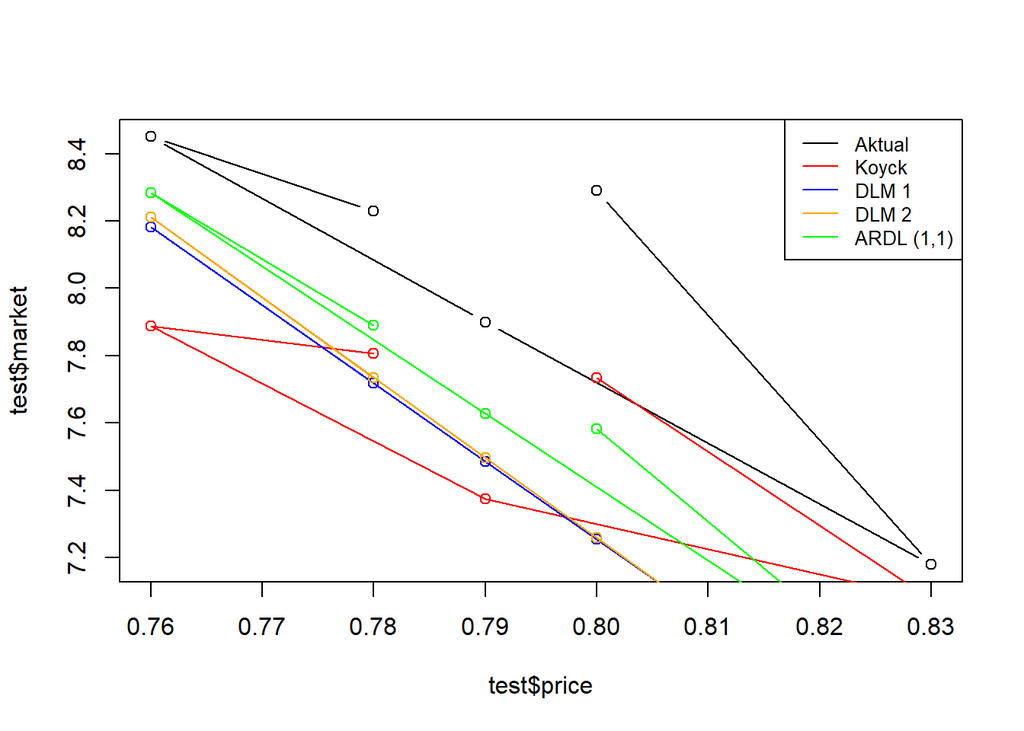

```r
par(mfrow=c(1,1))  # atur layout grafik tunggal

# plot data aktual
plot(test$price, test$market, type="b", col="black")

# Mwnambahkan garis ramalan dari masing-masing model
# (Koyck tetap pakai $forecasts karena berasal dari fungsi forecast() dLagM)
points(test$price, fore.koyck$forecasts, col="red");   lines(test$price, fore.koyck$forecasts, col="red")

# (DLM dan ARDL langsung memanggil nama objeknya)
points(test$price, fore.dlm1, col="blue");             lines(test$price, fore.dlm1, col="blue")
points(test$price, fore.dlm2, col="orange");           lines(test$price, fore.dlm2, col="orange")
points(test$price, fore.ardl2, col="green");           lines(test$price, fore.ardl2, col="green")

# legenda model (dipindah ke topright agar tidak menutupi garis grafik yang menurun)
legend("topright",
       c("Aktual", "Koyck", "DLM 1", "DLM 2", "ARDL (1,1)"),
       lty=1, col=c("black","red","blue","orange","green"), cex=0.8)
```

# data 2

```r
Year <- 1975:2014

Sales <- c(11.7, 12.0, 12.3, 12.8, 13.1, 13.6, 13.9, 14.4, 14.7, 15.3,
           15.5, 15.8, 16.1, 16.6, 16.9, 16.7, 16.9, 17.4, 17.6, 17.9,
           18.0, 17.9, 18.0, 18.2, 18.2, 18.3, 18.6, 19.2, 19.3, 19.5,
           19.2, 19.3, 19.5, 20.0, 20.0, 19.9, 19.8, 19.9, 20.2, 21.0)

Advertising <- c(9.4, 9.6, 10.0, 10.4, 10.8, 10.9, 11.7, 12.2, 12.5, 12.9,
                 13.0, 13.2, 13.8, 14.2, 14.6, 14.4, 15.0, 15.4, 15.7, 15.9,
                 15.9, 16.0, 16.3, 16.2, 16.8, 17.3, 17.6, 18.1, 18.3, 18.5,
                 18.7, 18.9, 19.2, 20.0, 20.0, 20.3, 20.4, 21.0, 21.5, 22.1)

dtsales <- data.frame(Year, Sales, Advertising)

dtsales
```

```
##    Year Sales Advertising
## 1  1975  11.7         9.4
## 2  1976  12.0         9.6
## 3  1977  12.3        10.0
## 4  1978  12.8        10.4
## 5  1979  13.1        10.8
## 6  1980  13.6        10.9
## 7  1981  13.9        11.7
## 8  1982  14.4        12.2
## 9  1983  14.7        12.5
## 10 1984  15.3        12.9
## 11 1985  15.5        13.0
## 12 1986  15.8        13.2
## 13 1987  16.1        13.8
## 14 1988  16.6        14.2
```

[output cut: 26 more lines]

```r
# 80% dari 40 = 32 baris (Tahun 1975 - 2006)
train <- dtsales[1:32, ]

# 20% dari 40 = 8 baris (Tahun 2007 - 2014)
test <- dtsales[33:40, ]

train.ts <- ts(train, start = 1975, frequency = 1)
```

```r
library(dynlm)

ardl_10 <- dynlm(Sales ~ Advertising + L(Sales), data = train.ts)

ardl_11 <- dynlm(Sales ~ Advertising + L(Advertising) + L(Sales), data = train.ts)

ardl_12 <- dynlm(Sales ~ Advertising + L(Advertising) + L(Advertising, 2) + L(Sales), data = train.ts)

ardl_22 <- dynlm(Sales ~ Advertising + L(Advertising) + L(Advertising, 2) + L(Sales) + L(Sales, 2), data = train.ts)
```

```r
# Membandingkan AIC dari keempat model
AIC(ardl_10, ardl_11, ardl_12, ardl_22)
```

```
##         df       AIC
## ardl_10  4 -13.35860
## ardl_11  5 -12.93737
## ardl_12  6 -14.83434
## ardl_22  7 -13.15225
```

```r
library(MLmetrics)

# Forecasting 8 periode ke depan (sesuai jumlah data test)
pred_10 <- predict(ardl_10, newdata = test)
pred_11 <- predict(ardl_11, newdata = test)
pred_12 <- predict(ardl_12, newdata = test)
pred_22 <- predict(ardl_22, newdata = test)

# Menghitung MAPE antara hasil prediksi dan data aktual (Sales di data test)
mape_10 <- MAPE(pred_10, test$Sales)
mape_11 <- MAPE(pred_11, test$Sales)
mape_12 <- MAPE(pred_12, test$Sales)
mape_22 <- MAPE(pred_22, test$Sales)

# Menggabungkan hasil akurasi ke dalam satu matriks
akurasi_ardl <- matrix(c(mape_10, mape_11, mape_12, mape_22))
row.names(akurasi_ardl) <- c("ARDL (1,0)", "ARDL (1,1)", "ARDL (1,2)", "ARDL (2,2)")
colnames(akurasi_ardl) <- c("MAPE")

# Menampilkan perbandingan akurasi
akurasi_ardl
```

```
##                   MAPE
## ARDL (1,0) 0.015060242
## ARDL (1,1) 0.009203471
## ARDL (1,2) 0.001293759
## ARDL (2,2) 0.001075658
```

Jika dilihat dari MAPE nya, model terbaiknya adalah ARDL (2,2)

```r
# ringkasan model terbaik
summary(ardl_22)
```

```
##
## Time series regression with "ts" data:
## Start = 1977, End = 2006
##
## Call:
## dynlm(formula = Sales ~ Advertising + L(Advertising) + L(Advertising,
##     2) + L(Sales) + L(Sales, 2), data = train.ts)
##
## Residuals:
##      Min       1Q   Median       3Q      Max
## -0.36544 -0.09269  0.00147  0.12317  0.36440
##
## Coefficients:
##                   Estimate Std. Error t value Pr(>|t|)
## (Intercept)        0.94909    0.56964   1.666 0.108689
## Advertising        0.33062    0.15447   2.140 0.042695 *
## L(Advertising)     0.07625    0.20900   0.365 0.718424
## L(Advertising, 2) -0.36116    0.17781  -2.031 0.053454 .
## L(Sales)           0.81182    0.18674   4.347 0.000218 ***
## L(Sales, 2)        0.09337    0.18465   0.506 0.617721
## ---
## Signif. codes:  0 '***' 0.001 '**' 0.01 '*' 0.05 '.' 0.1 ' ' 1
##
## Residual standard error: 0.1721 on 24 degrees of freedom
## Multiple R-squared:  0.9946, Adjusted R-squared:  0.9934
## F-statistic: 880.3 on 5 and 24 DF,  p-value: < 2.2e-16
```

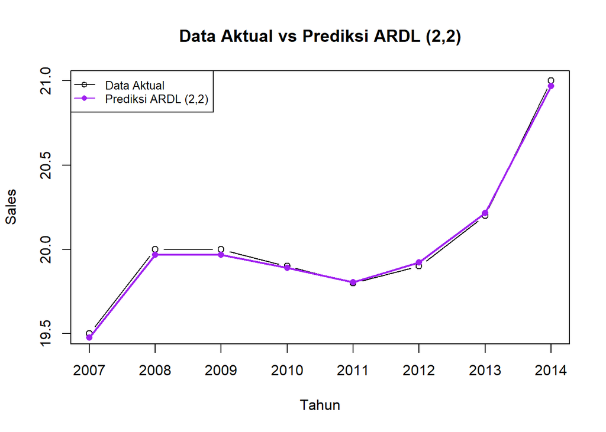

```r
# Plot Visualisasi
par(mfrow=c(1,1))

# Plot data aktual dari data testing (Sales)
plot(test$Year, test$Sales, type="b", col="black",
     xlab="Tahun", ylab="Sales", main="Data Aktual vs Prediksi ARDL (2,2)")

# Menambahkan titik dan garis dari hasil ramalan model ARDL (2,2)
# (Menggunakan objek pred_22 yang sudah dibuat pada langkah akurasi sebelumnya)
points(test$Year, pred_22, col="purple", pch=16)
lines(test$Year, pred_22, col="purple", lwd=2)

legend("topleft",
       legend = c("Data Aktual", "Prediksi ARDL (2,2)"),
       lty = 1, col = c("black", "purple"), pch = c(1, 16), cex = 0.8)
```

Berdasarkan hasil summary dari estimasi model ARDL (2,2), diperoleh kesimpulan dan interpretasi sebagai berikut:

1. Persamaan Model
   Persamaan matematis untuk model peramalan yang terbentuk adalah:
   $$\hat{Y}_t = 0.9491 + 0.3306 X_t + 0.0762
   X_{t-1} - 0.3612 X_{t-2} + 0.8118 Y_{t-1} + 0.0934 Y_{t-2}$$
   Keterangan: $Y$ merepresentasikan Sales dan $X$ merepresentasikan Advertising.
2. Pengujian Signifikansi Parsial (Uji t)  
   Berdasarkan tingkat signifikansi $5\%$ ($0.05$), diperoleh keputusan:
- Saat Ini ($X_t$): Berpengaruh signifikan terhadap penjualan karena nilai P-Value = $0.0427$ < $0.05$. Nilai koefisien bernilai positif, yang berarti peningkatan pengeluaran iklan di tahun berjalan akan secara langsung menaikkan penjualan.
- Sales Satu Tahun Sebelumnya ($Y_{t-1}$): Berpengaruh sangat signifikan terhadap penjualan saat ini karena nilai P-Value = $0.0002$ < $0.05$. Hal ini mengindikasikan adanya efek momentum yang kuat dari penjualan tahun sebelumnya.
- Variabel Lag Lainnya:Lag $1$ Advertising ($X_{t-1}$), Lag $2$ Advertising ($X_{t-2}$), dan Lag $2$ Sales ($Y_{t-2}$) secara parsial tidak berpengaruh signifikan terhadap Sales karena masing-masing memiliki nilai P-Value > $0.05$.
3. Kebaikan Model
- Uji Simultan (Uji F): Peubah independen beserta seluruh variabel lag-nya secara bersama-sama berpengaruh sangat signifikan terhadap Sales saat ini. Hal ini dibuktikan dengan nilai P-Value < $2.2 \times 10^{-16}$.
- Koefisien Determinasi ($R^2$): Nilai Multiple R-squared sebesar $0.9946$ (atau $99.46\%$) menunjukkan bahwa model yang dibangun sangat kuat dan presisi. Model berhasil menjelaskan keragaman data Sales sebesar $99.46\%$, dan hanya $0.54\%$ sisanya yang dipengaruhi oleh peubah lain di luar model.